# Problems set 3

## Diamonds

Load the ‘diamonds’ data set in R studio.

```r
library(ggplot2)
data(diamonds)

observations <- dim(diamonds)[1]
observations
```

```
## [1] 53940
```

```r
vars <- dim(diamonds)[2]
vars
```

```
## [1] 10
```

```r
# Ordered factors (count 'manually' vars with Ord. factor description)
# Ans : 3
str(diamonds)
```

```
## 'data.frame':    53940 obs. of  10 variables:
##  $ carat  : num  0.23 0.21 0.23 0.29 0.31 0.24 0.24 0.26 0.22 0.23 ...
##  $ cut    : Ord.factor w/ 5 levels "Fair"<"Good"<..: 5 4 2 4 2 3 3 3 1 3 ...
##  $ color  : Ord.factor w/ 7 levels "D"<"E"<"F"<"G"<..: 2 2 2 6 7 7 6 5 2 5 ...
##  $ clarity: Ord.factor w/ 8 levels "I1"<"SI2"<"SI1"<..: 2 3 5 4 2 6 7 3 4 5 ...
##  $ depth  : num  61.5 59.8 56.9 62.4 63.3 62.8 62.3 61.9 65.1 59.4 ...
##  $ table  : num  55 61 65 58 58 57 57 55 61 61 ...
##  $ price  : int  326 326 327 334 335 336 336 337 337 338 ...
##  $ x      : num  3.95 3.89 4.05 4.2 4.34 3.94 3.95 4.07 3.87 4 ...
##  $ y      : num  3.98 3.84 4.07 4.23 4.35 3.96 3.98 4.11 3.78 4.05 ...
##  $ z      : num  2.43 2.31 2.31 2.63 2.75 2.48 2.47 2.53 2.49 2.39 ...
```

```r
# What letter represents the best color for a diamond?
# Levels: D < E < F < G < H < I < J
# Ans : D (?diamonds: colour. diamond colour, from J (worst) to D (best))
# factor(diamonds$color)
levels(diamonds$color)
```

```
## [1] "D" "E" "F" "G" "H" "I" "J"
```

## Price histogram

Create a histogram of the price of all the diamonds in the diamond data set.

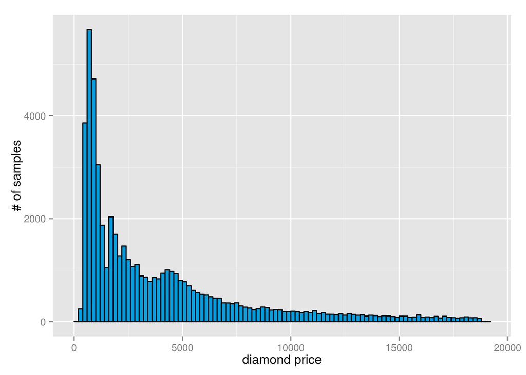

```r
ggplot(aes(x=price), data=diamonds) +
  geom_histogram(binwidth=200, color='black', fill='#02a0e2') +
  xlab("diamond price") +
  ylab("# of samples")
```

## Price Histogram Summary

Describe the shape and center of price distribution.

Long tailed.

```r
mean(diamonds$price)
```

```
## [1] 3932.8
```

```r
median(diamonds$price)
```

```
## [1] 2401
```

## Diamond counts

How many diamonds cost less than $500?

```r
sum(diamonds$price < 500)
```

```
## [1] 1729
```

How many diamonds cost less than $250?

```r
sum(diamonds$price < 250)
```

```
## [1] 0
```

How many diamonds cost $15000 or more?

```r
sum(diamonds$price >= 15000)
```

```
## [1] 1656
```

## Cheaper Diamonds

Explore the largest peak in the price histogram you created earlier.

Try limiting the x-axis, altering the bin width, and setting different breaks on the x-axis.

There won’t be a solution video for this question so go to the discussions to share your thoughts and discover what other people find.

You can save images by using the ggsave() command. ggsave() will save the last plot created. For example…

```
qplot(x = price, data = diamonds)
ggsave('priceHistogram.png')
```

ggsave currently recognises the extensions eps/ps, tex (pictex), pdf, jpeg, tiff, png, bmp, svg and wmf (windows only).

Submit your final code when you are ready.

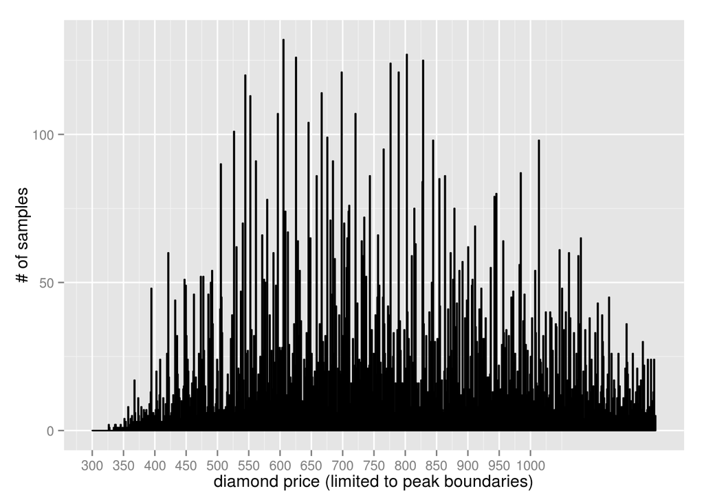

```r
ggplot(aes(x=price), data=diamonds) +
  geom_histogram(binwidth=1, color='black', fill='#02a0e2') +
  scale_x_continuous(limits = c(300, 1200), breaks = seq(0, 1000, 50)) +
  xlab("diamond price (limited to peak boundaries)") +
  ylab("# of samples")
```

Findings: - most diamonds fall into [500, 900] interval - most common prices are round ones: x00, x25, x50, x75 - diamonds price = 605 is the most common

## Price by cut

Break out the histogram of diamond prices by cut.

You should have five histograms in separate panels on your resulting plot.

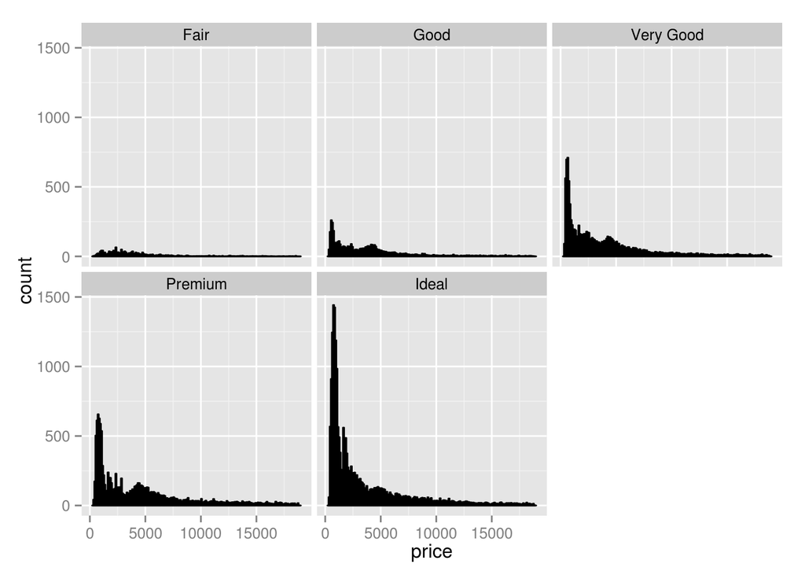

```r
ggplot(aes(x=price), data=diamonds) +
  geom_histogram(binwidth=100, color='black', fill='#02a0e2') +
  facet_wrap(~cut)
```

## Price by Cut

Which cut has the highest priced diamond?

```r
highest_priced <- diamonds[diamonds$price == max(diamonds$price), ]
highest_priced$cut
```

```
## [1] Premium
## Levels: Fair < Good < Very Good < Premium < Ideal
```

Which cut has the lowest priced diamond?

```r
lowest_priced <- diamonds[diamonds$price == min(diamonds$price), ]
lowest_priced$cut
```

```
## [1] Ideal   Premium
## Levels: Fair < Good < Very Good < Premium < Ideal
```

Which cut has the lowest median price?

```r
medians <- by(diamonds$price, diamonds$cut, median)
medians[medians == min(medians)]
```

```
## Ideal
##  1810
```

## Scales and Multiple Histograms

```
## stat_bin: binwidth defaulted to range/30. Use 'binwidth = x' to adjust this.
## stat_bin: binwidth defaulted to range/30. Use 'binwidth = x' to adjust this.
## stat_bin: binwidth defaulted to range/30. Use 'binwidth = x' to adjust this.
## stat_bin: binwidth defaulted to range/30. Use 'binwidth = x' to adjust this.
## stat_bin: binwidth defaulted to range/30. Use 'binwidth = x' to adjust this.
```

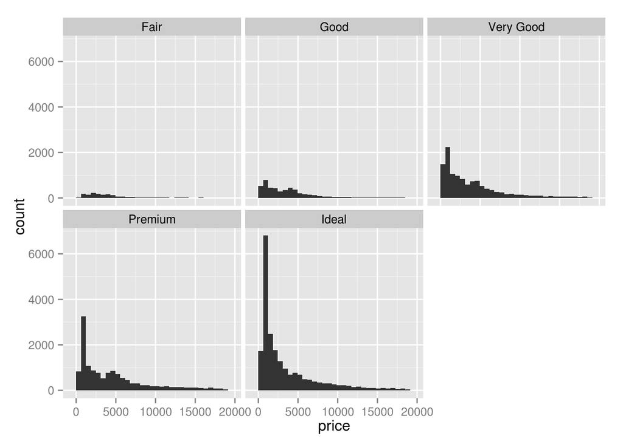

```r
# In the two last exercises, we looked at the distribution for diamonds by cut.
# Run the code below in R Studio to generate the histogram as a reminder.
qplot(x = price, data = diamonds) + facet_wrap(~cut)
```

```r
by(diamonds$price, diamonds$cut, summary)
```

```
## diamonds$cut: Fair
##    Min. 1st Qu.  Median    Mean 3rd Qu.    Max.
##     337    2050    3282    4359    5206   18570
## --------------------------------------------------------
## diamonds$cut: Good
##    Min. 1st Qu.  Median    Mean 3rd Qu.    Max.
##     327    1145    3050    3929    5028   18790
## --------------------------------------------------------
## diamonds$cut: Very Good
##    Min. 1st Qu.  Median    Mean 3rd Qu.    Max.
##     336     912    2648    3982    5373   18820
## --------------------------------------------------------
## diamonds$cut: Premium
##    Min. 1st Qu.  Median    Mean 3rd Qu.    Max.
##     326    1046    3185    4584    6296   18820
## --------------------------------------------------------
## diamonds$cut: Ideal
##    Min. 1st Qu.  Median    Mean 3rd Qu.    Max.
##     326     878    1810    3458    4678   18810
```

This means the distributions should be somewhat similar but the histograms we created don’t show that.

The ‘Fair’ and ‘Good’ diamonds appear to have different distributions compared to the better cut diamonds. They seem somewhat uniform on the left with long tails on the right.

Let’s look in to this more.

Look up the documentation for facet_wrap in R Studio. Then, scroll back up and add a parameter to facet_wrap so that the y-axis in the histograms is not fixed. You want the y-axis to be different for each histogram.

If you want a hint, check out the Instructor Notes (http://www.cookbook-r.com/Graphs/Facets_(ggplot2))

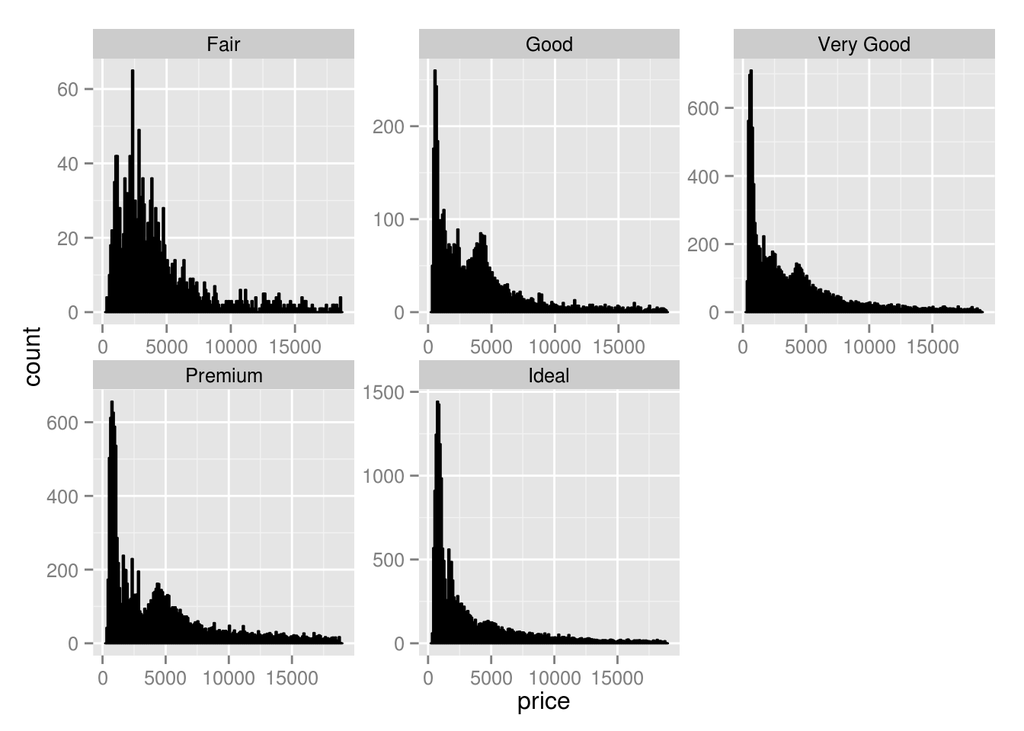

```r
ggplot(aes(x=price), data=diamonds) +
  geom_histogram(binwidth=100, color='black', fill='#02a0e2') +
  facet_wrap(~cut, scales="free")
```

## Price per Carat by Cut

Create a histogram of price per carat and facet it by cut. You can make adjustments to the code from the previous exercise to get started.

Adjust the bin width and transform the scale of the x-axis using log10.

Hint 1: You use the price and carat variables in the parameter for x. What expression gives you price per carat? Hint 2: For long tailed distributions, you can add a ggplot layer such as scale_x_log10() to transform the variable.

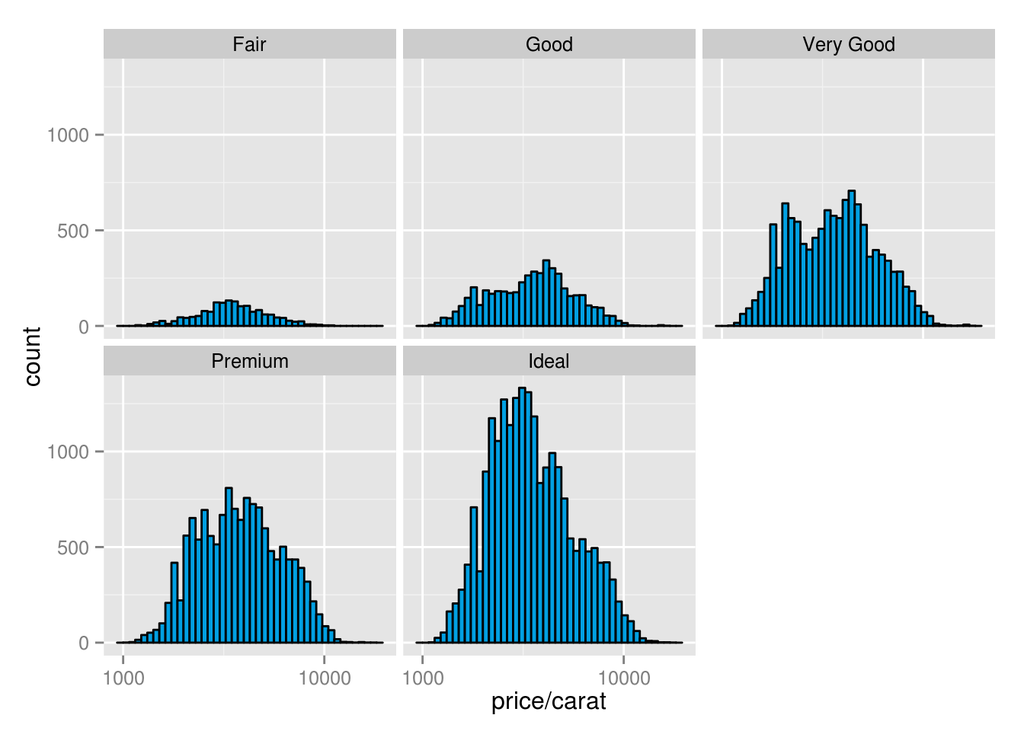

```r
ggplot(aes(x=price/carat), data=diamonds) +
  geom_histogram(binwidth=0.03, color='black', fill='#02a0e2') +
  scale_x_log10() +
  facet_wrap(~cut, scales="fixed")
```

Did you find normal-ish distributions and a slightly bimodal distribution for Very Good cuts? (If the Very Good facet looks smooth, try decreasing your bin width! If the data looks skewed, did you remember to perform a log10 transform?)

## Price Box Plots

Investigate the price of diamonds using box plots, numerical summaries, and one of the following categorical variables: cut, clarity, or color.

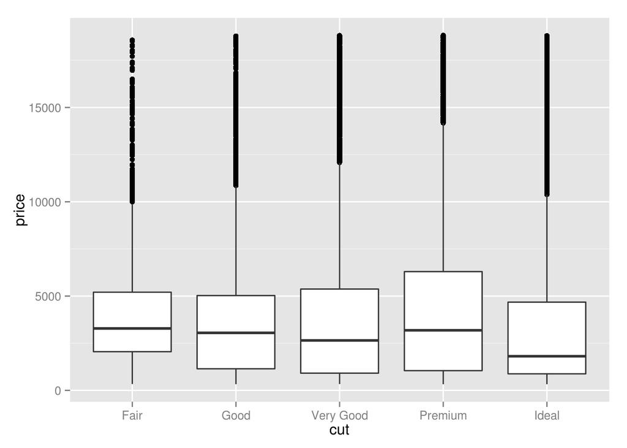

```r
ggplot(aes(x = cut, y = price), data=diamonds) +
  # remove the outliers
  # coord_cartesian(ylim = c(0, 8000)) +
  geom_boxplot()
```

```r
by(diamonds$price, diamonds$cut, summary)
```

```
## diamonds$cut: Fair
##    Min. 1st Qu.  Median    Mean 3rd Qu.    Max.
##     337    2050    3282    4359    5206   18570
## --------------------------------------------------------
## diamonds$cut: Good
##    Min. 1st Qu.  Median    Mean 3rd Qu.    Max.
##     327    1145    3050    3929    5028   18790
## --------------------------------------------------------
## diamonds$cut: Very Good
##    Min. 1st Qu.  Median    Mean 3rd Qu.    Max.
##     336     912    2648    3982    5373   18820
## --------------------------------------------------------
## diamonds$cut: Premium
##    Min. 1st Qu.  Median    Mean 3rd Qu.    Max.
##     326    1046    3185    4584    6296   18820
## --------------------------------------------------------
## diamonds$cut: Ideal
##    Min. 1st Qu.  Median    Mean 3rd Qu.    Max.
##     326     878    1810    3458    4678   18810
```

## Interquartile Range - IQR

What is the price range for the middle 50% of diamonds with color D?

```r
d_color <- diamonds[diamonds$color == "D", ]
quantile(d_color$price, 1/4)
```

```
## 25%
## 911
```

```r
quantile(d_color$price, 3/4)
```

```
##    75%
## 4213.5
```

```r
quantile(d_color$price, 3/4) - quantile(d_color$price, 1/4)
```

```
##    75%
## 3302.5
```

What is the price range for the middle 50% of diamonds with color J?

```r
j_color <- diamonds[diamonds$color == "J", ]
quantile(j_color$price, 1/4)
```

```
##    25%
## 1860.5
```

```r
quantile(j_color$price, 3/4)
```

```
##  75%
## 7695
```

```r
quantile(j_color$price, 3/4) - quantile(j_color$price, 1/4)
```

```
##    75%
## 5834.5
```

## Price per Carat Box Plots by Color

Investigate the price per carat of diamonds across the different colors of diamonds using boxplots. (http://www.lumeradiamonds.com/diamond-education/diamond-color)

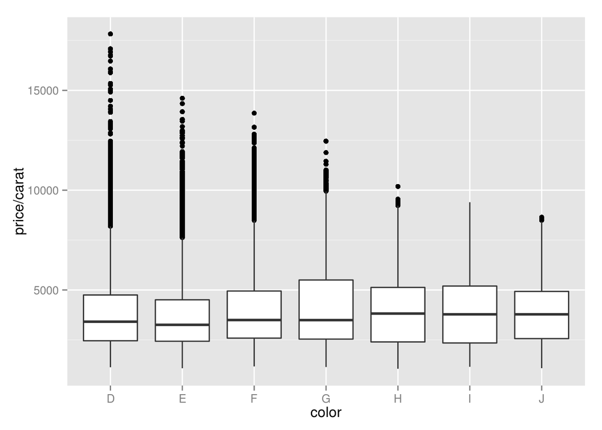

```r
# TODO(pawelb): how to assign different colours to factors/colors?
ggplot(aes(x = color, y = price/carat), data=diamonds) +
  # remove the outliers
  #coord_cartesian(ylim = c(0, 8000)) +
  geom_boxplot()
```

## Carat Frequency Polygon

Investigate the weight of the diamonds (carat) using frequecny poligon. Use different bin widhts to see how the frequency polygon changes. What carat size has a count greater than 2000?

Ans: 0.3, 1.01

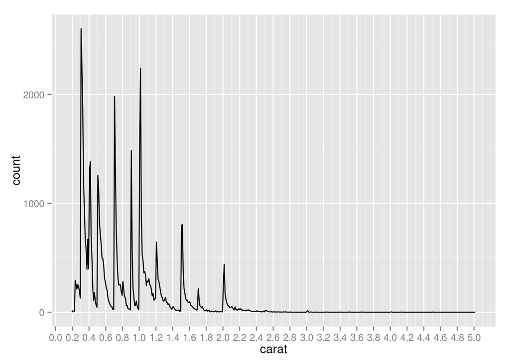

```r
ggplot(aes(x = carat, y = ..count..), data=diamonds) +
  geom_freqpoly(binwidth=0.01) +
  scale_x_continuous(breaks=seq(0, 5, 0.2))
```

## Data Wrangling with R

Links: Data Wrangling in R: https://s3.amazonaws.com/udacity-hosted-downloads/ud651/DataWranglingWithR.pdf Data Wrangling Cheat Sheet: https://www.rstudio.com/wp-content/uploads/2015/02/data-wrangling-cheatsheet.pdf

## Gapminder Data

Using ‘Child per woman (total fertility)’: http://spreadsheets.google.com/pub?key=tGdhNYGTGtunwzkKJ9aRhsA&gid=0

```r
library(openxlsx)
#library(Hmisc)
library(tidyr)
library(dplyr)
```

```
## stat_bin: binwidth defaulted to range/30. Use 'binwidth = x' to adjust this.
```

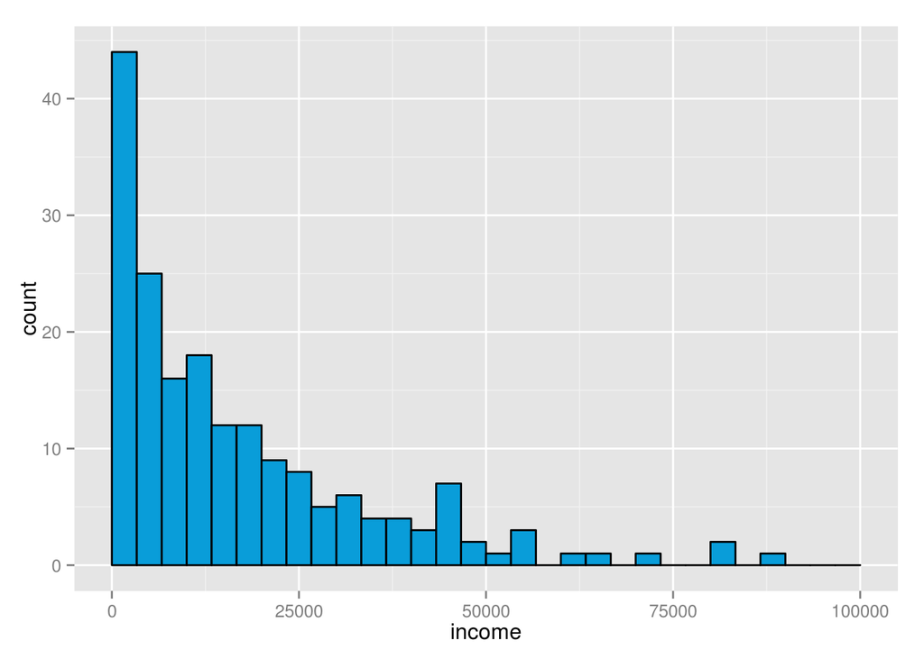

```r
library(ggplot2)
# There is problem with row=260 ('Aland') which causes error on making rowNames from 1st column, thus we skip it.
fertility <- read.xlsx('indicator undata total_fertility.xlsx', rowNames = TRUE, rows=1:259)
fertility <- mutate(fertility, country=rownames(fertility))
#pl_fertility = gather(fertility['Poland',], year, "fertility", 1:length(fertility))
fertility2 <- gather(fertility, year, "fertility", 1:(length(fertility)-1), convert=TRUE)
fertility2 <- arrange(fertility2, country, year)

# income has one empty row in the end
income <- read.xlsx('indicator gapminder gdp_per_capita_ppp.xlsx', rowNames = TRUE, rows=1:260)
income <- mutate(income, country=rownames(income))
income2 <- gather(income, year, "fertility", 1:(length(income)-1), convert = TRUE)
income2 <- arrange(income2, country, year)

fer_inc <- inner_join(income2, fertility2, by = c("country", "year"))
names(fer_inc) <- c("country", "year", "income", "fertility")

fer_inc_2015 <- fer_inc[fer_inc$year == 2015 & !is.na(fer_inc$income) & !is.na(fer_inc$fertility),]

# income in 2015 (# of countries)
ggplot(aes(x=income), data = fer_inc_2015) +
  geom_histogram(color = 'black', fill = '#099DD9') +
  scale_x_continuous(limits = c(0, 100000), breaks = seq(0, 100000, 25000))
```

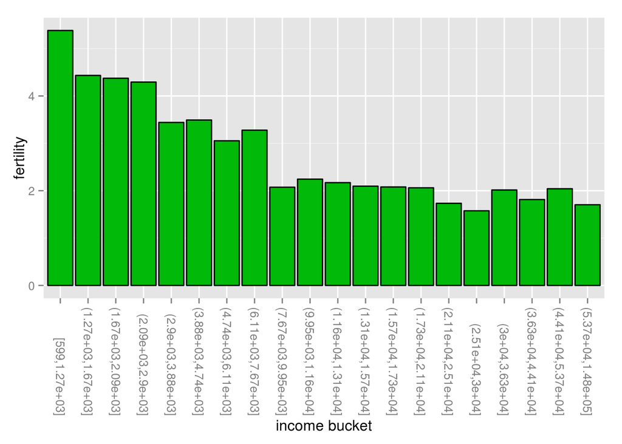

```r
# histogram of fertility as funciof of income (income in buckets)
# cut_number cuts number vector into intervals containing equal number of points
ggplot(aes(x=cut_number(income, n=20), y=fertility), data = fer_inc_2015)  +
  geom_bar(stat = "summary", fun.y = "mean", color = 'black', fill = '#00B909') +
  theme(axis.text.x = element_text(angle = 270, hjust = 1, vjust=0.5)) +
  xlab("income bucket")
```

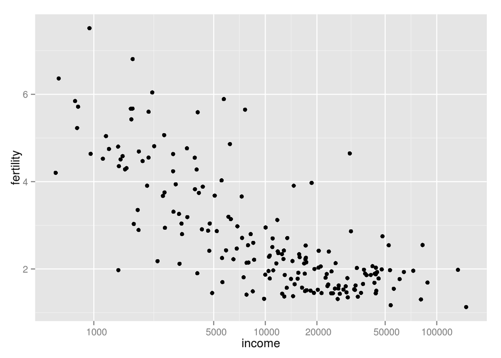

```r
# fertility as function of income
# we add custom labels formatter to see numbers instead of scientific notation
ggplot(aes(x=income, y=fertility), data = fer_inc_2015) + geom_jitter() +
  scale_x_log10(breaks=c(1000, 5000, 10000, 20000, 50000, 100000), labels=function(n){format(n, scientific = FALSE)})
```

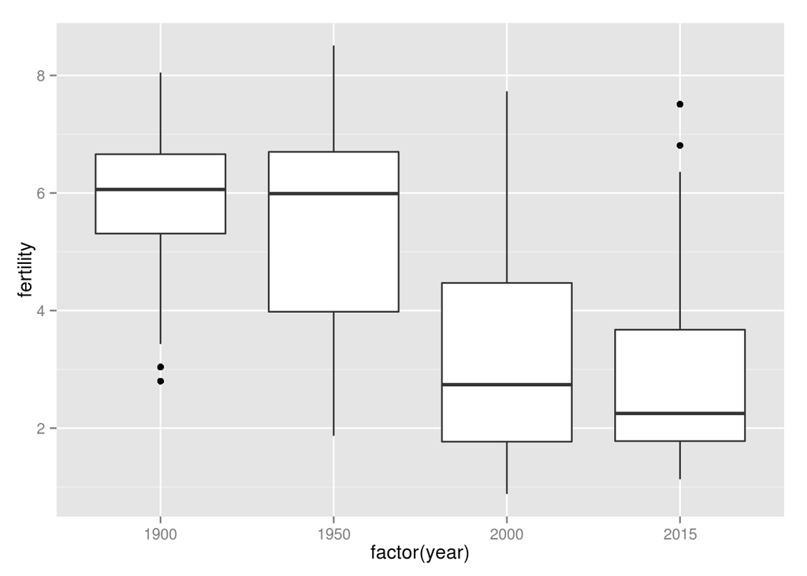

```r
# how did fertility changed in years?
fer_inc_cent <- fer_inc[fer_inc$year %in% c(1900, 1950, 2000, 2015) & !is.na(fer_inc$income) & !is.na(fer_inc$fertility),]
ggplot(aes(x = factor(year), y = fertility), data = fer_inc_cent) + geom_boxplot()
```

## Exploring Your Friends’ Birthdays

Using sample file: birthdaysExample.csv

```r
bday <- read.csv('pawelb_friends_birthday.csv')
bday <- separate(bday, 'bday', c("month", "day", "year"), sep="/")
bday <- arrange(bday[, c('month', 'day')], month, day)

# Which month contains the most number of birthdays?
bday_cnt <- table(bday$month)
bday_cnt[bday_cnt == max(bday_cnt)]
```

```
## 06
## 31
```

```r
# How many birthdays are in each month?
table(bday$month)
```

```
##
## 01 02 03 04 05 06 07 08 09 10 11 12
## 22 11 17 26 17 31 20 23 21 13 19 20
```

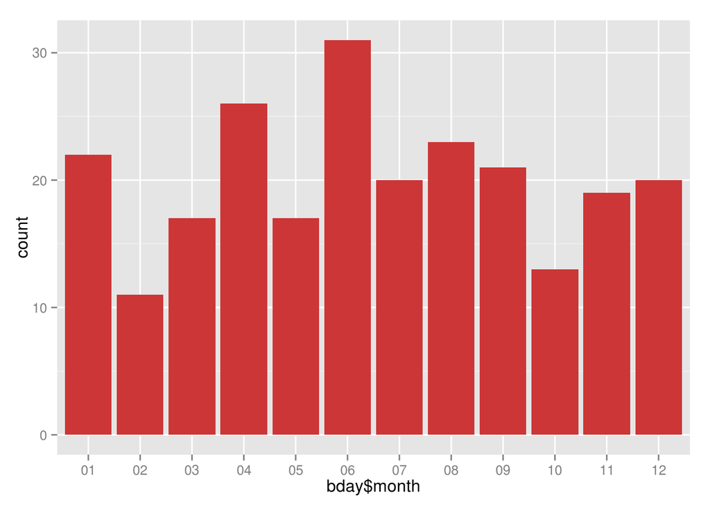

```r
ggplot(aes(x = bday$month), data = bday) + geom_histogram(fill = '#cc3637')
```

```r
# Which day of the year has the most number of birthdays?
summary(as.factor(paste0(bday$month, '-', bday$day)))[1:3]
```

```
## 06-10 04-21 05-01
##     5     3     3
```

```r
# Do you have at least 365 friends that have birthdays on everyday of the year?
days = data.frame(seq(as.Date("2015-01-01"), as.Date("2015-12-31"), by="1 day"))
names(days) <- c('day')
days <- separate(days, day, c("year", "month", "day"), sep="-")
days <- arrange(days[, c('month', 'day')], month, day)
missing_days = anti_join(days, bday, by = c("month", "day"))
dim(missing_days)
```

```
## [1] 182   2
```